# **Stat 112 - Recitation 10**

> Ozancan Ozdemir - ozancan@metu.edu.tr

## **Data Visualization with Pandas**

Pandas offers various tools for creating clear and insightful visualizations to aid in data analysis, which utilize matplotlib. These tools allow for easy comparison of different parts of a dataset, exploration of the entire dataset, and identification of patterns and correlations in the data.

The primary tool in pandas for creating visualizations is the `plot()` method, which is available for both Series and DataFrames. This method includes a parameter called `kind` that determines the type of plot to be generated. The available options for `kind` are listed below.

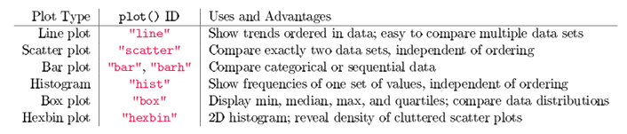

The **plot ID** is the value of the keyword argument kind. That is, df.plot(kind="scatter") creates a scatter plot. The default kind is "line".

In Pandas, there are two different way of using `plot()` method. The first one,

```
df.plot(kind='<kind of the desired plot e.gbar, area etc>', x,y)
```

The second one

```
df.plot.<kind of the desired plot e.gbar, area, etc>()
```

where **df** indicates the working data frame.

You can use any of them until as long as it works correctly.

Import the necessary packages.

```python
import pandas as pd
import numpy as np
import matplotlib.pyplot as plt

# set the plots to display in the Jupyter notebook
%matplotlib inline
```

The `plt` interface is what we will use most often.

Consider `avocado.csv` dataset.

The variable explanations are given below.

- Date - The date of the observation
- AveragePrice - the average price of a single avocado
- type - conventional or organic
- year - the year
- Region - the city or region of the observation
- Total Volume - Total number of avocados sold
- Small Hass - Total number of avocados with Small Hass sold
- Large Hass - Total number of avocados with Large Hass sold
- Extra Large Hass - Total number of avocados with Large Hass sold

```python
avocado = pd.read_csv('avocado.csv')
avocado = avocado.drop('Unnamed: 0',axis  = 1) #drop the unnecessary unnamed:0 column
avocado.head(5)
```

|  | Date | AveragePrice | Total Volume | Small Hass | Large Hass | Extra Large Hass | Total Bags | Small Bags | Large Bags | XLarge Bags | type | year | region |
| --- | --- | --- | --- | --- | --- | --- | --- | --- | --- | --- | --- | --- | --- |
| 0 | 2015-12-27 | 1.33 | 64236.62 | 1036.74 | 54454.85 | 48.16 | 8696.87 | 8603.62 | 93.25 | 0.0 | conventional | 2015 | Albany |
| 1 | 2015-12-20 | 1.35 | 54876.98 | 674.28 | 44638.81 | 58.33 | 9505.56 | 9408.07 | 97.49 | 0.0 | conventional | 2015 | Albany |
| 2 | 2015-12-13 | 0.93 | 118220.22 | 794.70 | 109149.67 | 130.50 | 8145.35 | 8042.21 | 103.14 | 0.0 | conventional | 2015 | Albany |
| 3 | 2015-12-06 | 1.08 | 78992.15 | 1132.00 | 71976.41 | 72.58 | 5811.16 | 5677.40 | 133.76 | 0.0 | conventional | 2015 | Albany |
| 4 | 2015-11-29 | 1.28 | 51039.60 | 941.48 | 43838.39 | 75.78 | 6183.95 | 5986.26 | 197.69 | 0.0 | conventional | 2015 | Albany |

```python
avocado.info()
```

```
<class 'pandas.core.frame.DataFrame'>
RangeIndex: 18249 entries, 0 to 18248
Data columns (total 13 columns):
 #   Column            Non-Null Count  Dtype
---  ------            --------------  -----
 0   Date              18249 non-null  object
 1   AveragePrice      18249 non-null  float64
 2   Total Volume      18249 non-null  float64
 3   Small Hass        18249 non-null  float64
 4   Large Hass        18249 non-null  float64
 5   Extra Large Hass  18249 non-null  float64
 6   Total Bags        18249 non-null  float64
 7   Small Bags        18249 non-null  float64
 8   Large Bags        18249 non-null  float64
 9   XLarge Bags       18249 non-null  float64
 10  type              18249 non-null  object
 11  year              18249 non-null  int64
 12  region            18249 non-null  object
dtypes: float64(9), int64(1), object(3)
memory usage: 1.8+ MB
```

❓**How does the average price change over time?**

I will explore the behaviour of average price over time. Since my intentition is to observe a pattern by time, **line plot** is the best choice. Notice that the default kind of the `plot` function is **line**.

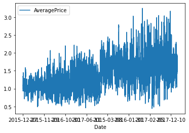

```python
avocado.plot('Date','AveragePrice')
```

Let's customize this plot using additional arguments in **plot**.

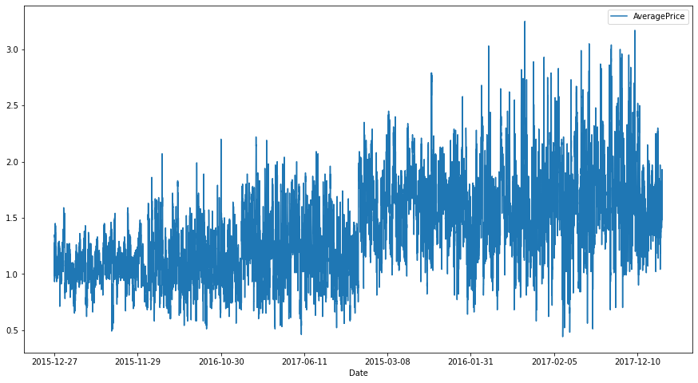

```python
avocado.plot('Date','AveragePrice',figsize = (15,8)) #figsize specifies the size of the figure object.
```

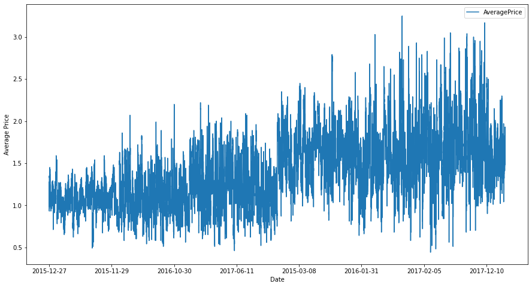

```python
avocado.plot('Date','AveragePrice',figsize = (15,8),
             xlabel = 'Date', ylabel = "Average Price") #xlabel & ylabel set axis title for x and y axis.
```

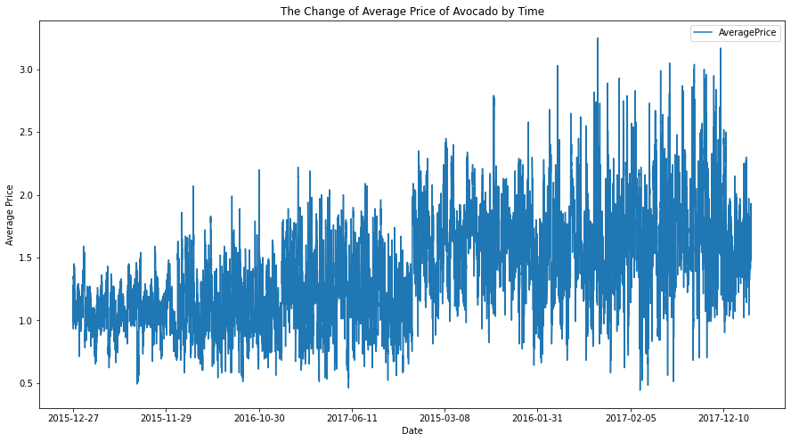

```python
avocado.plot('Date','AveragePrice',figsize = (15,8),
             xlabel = 'Date', ylabel = "Average Price",
             title = 'The Change of Average Price of Avocado by Time') #title set the title of the plot
```

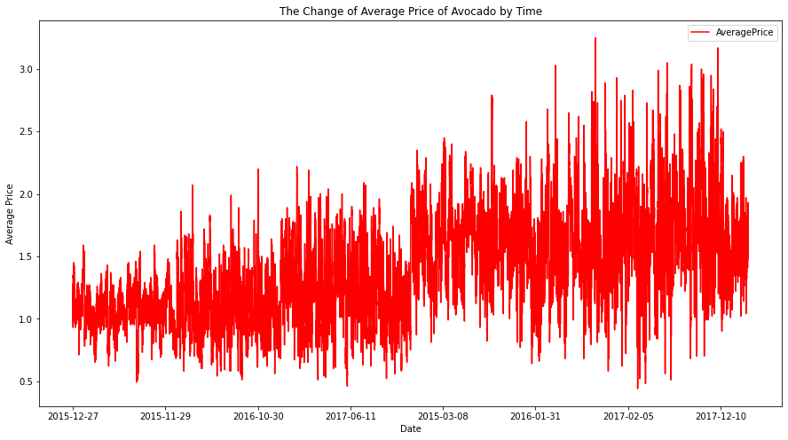

```python
avocado.plot('Date','AveragePrice',figsize = (15,8),
             xlabel = 'Date', ylabel = "Average Price",
             title = 'The Change of Average Price of Avocado by Time',
             color = 'Red') #color changes the color of your plot
```

❓**How does the hass types change over time?**

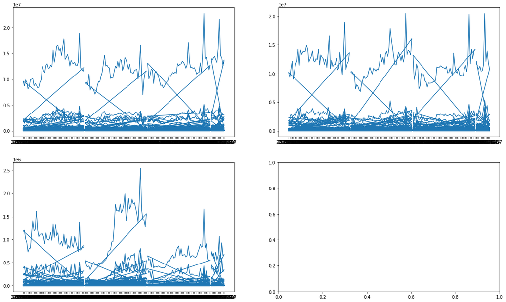

```python
fig, axs = plt.subplots(nrows=2, ncols=2,figsize = (20,12)) #subplots is an attribute from matplotlib and Create a figure and a set of subplots.
axs[0,0].plot(avocado['Date'],avocado['Small Hass'])
axs[0,1].plot(avocado['Date'],avocado['Large Hass'])
axs[1,0].plot(avocado['Date'], avocado['Extra Large Hass'])
```

It is certainly ugly plot, but you should focus on how to draw a multiple plot in one window.

❓**What is the distribution of type of avocados?**

Note that avocado has an object data type, implying that it is a categorical variable. Remember that we use **bar plot** to display the frequency/distribution of the categorical variable.

Drawing a bar plot using pandas may require a simple data manipulation/calculation

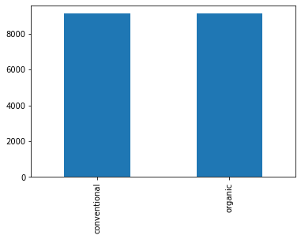

```python
avocado['type'].value_counts().plot(kind = 'bar') # basic bar plot
```

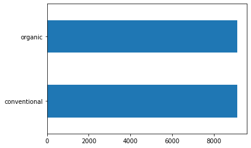

```python
avocado['type'].value_counts().plot(kind = 'barh') #horizontal bar plot
```

### Knowledge Check

Which type of bar plot can be used in this example? Explain your reasoning.

You can use the customization argument specified above to customize your bar plot.

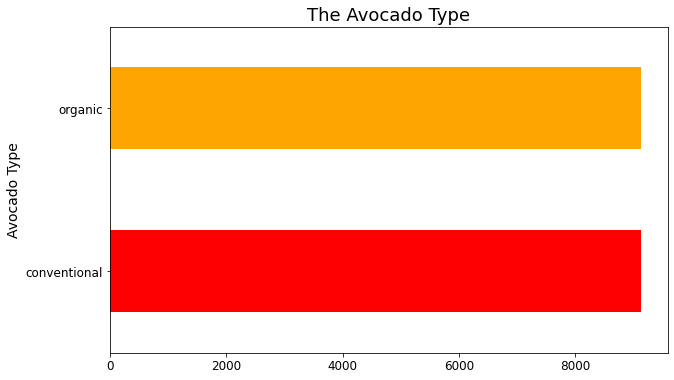

```python
## Customize your plot

avocado['type'].value_counts().plot(kind = 'barh', figsize = (10,6), color = ['Red','Orange'],
                                    fontsize = 12) #fontsize: Font size for xticks and yticks
#plt.xlabel('xlabel', fontsize=14)
plt.ylabel('Avocado Type', fontsize=14)
plt.title('The Avocado Type', fontsize = 18) #set the title and font size
```

Let's add counts on the top of the bars... 😢

It takes longer time.

```python
freq_table = pd.DataFrame(avocado['type'].value_counts())
freq_table
```

|  | type |
| --- | --- |
| conventional | 9126 |
| organic | 9123 |

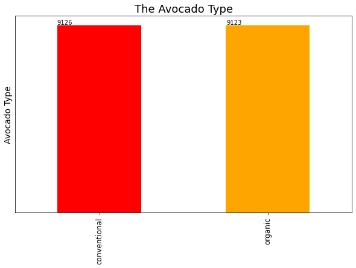

```python
ax = freq_table['type'].plot(kind = 'bar', figsize = (10,6), color = ['Red','Orange'],
                                    fontsize = 12)

plt.ylabel('Avocado Type', fontsize=14)
plt.title('The Avocado Type', fontsize = 18) #set the title and font size
#plt.xticks([]) #remove x axis text
plt.yticks([]) #remove y axis text.

for p in ax.patches:
    ax.annotate(str(p.get_height()), (p.get_x() * 1.005, p.get_height() * 1.005))
plt.show()
```

❓**What is the distribution of Average Price?**

Since average price is a numerical value, the shape of the distribution of this can be assessed by **histogram.**

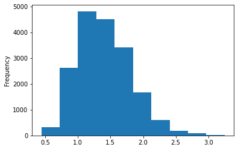

```python
avocado['AveragePrice'].plot(kind = 'hist')
```

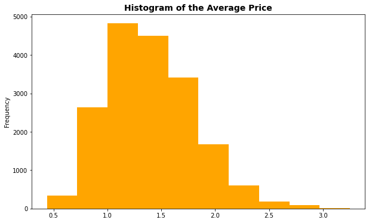

```python
## Customize

avocado['AveragePrice'].plot(kind = 'hist', color ="orange", figsize = (10,6))
plt.title("Histogram of the Average Price", fontsize = 14,fontweight='bold') #fontweight: bold makes your title bold.
```

### Knowledge Check

What is the default number of bin in pandas histogram?

❓**How does the distribution of large hass and extra large hass differ from each other?**

You can compare the shape of the distribution of the two numerical variable on the same plot. Here the **alpha** is the key parameter.

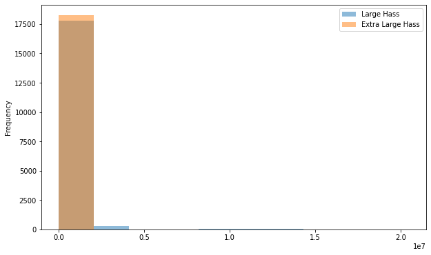

```python
avocado[['Large Hass', 'Extra Large Hass']].plot(kind = 'hist', alpha = 0.5, figsize = (10,6))
```

**You can customize your plot using the functions and argument listed above.**

❓**How does the distribution of average price chage by avocado type?**

The variable of interests are one numerical and one categorical variable, **box plot** will be an appropriate choice.

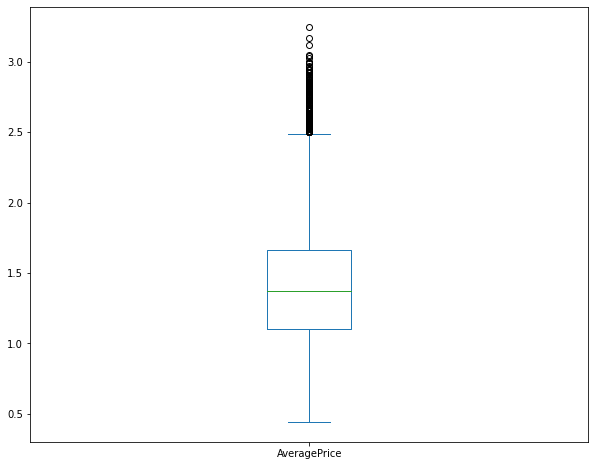

```python
avocado[['AveragePrice','type']].plot(kind = 'box',figsize=(10, 8))
#column: numerical variable & by: categorical variable
```

**Upps..** We have a problem because the data is not in the appropriate form.

```python
subdata = avocado[['AveragePrice','type']]
subdata.head()
```

|  | AveragePrice | type |
| --- | --- | --- |
| 0 | 1.33 | conventional |
| 1 | 1.35 | conventional |
| 2 | 0.93 | conventional |
| 3 | 1.08 | conventional |
| 4 | 1.28 | conventional |

**Solution:** Reshape the data

```python
subdata_wider = subdata.pivot(columns="type", values="AveragePrice")
subdata_wider
```

| type | conventional | organic |
| --- | --- | --- |
| 0 | 1.33 | NaN |
| 1 | 1.35 | NaN |
| 2 | 0.93 | NaN |
| 3 | 1.08 | NaN |
| 4 | 1.28 | NaN |
| ... | ... | ... |
| 18244 | NaN | 1.63 |
| 18245 | NaN | 1.71 |
| 18246 | NaN | 1.87 |
| 18247 | NaN | 1.93 |
| 18248 | NaN | 1.62 |

18249 rows × 2 columns

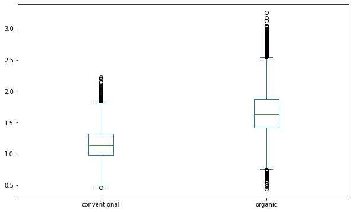

```python
subdata_wider.plot(kind = 'box', figsize = (10,6))
```

**You can customize your plot using the functions and argument listed above.**

❓**What is the relationship between Small Hass and Small Bags?**

Since we aim to investigate the relationship between **two numerical** variables, we can use **scatter plot**.

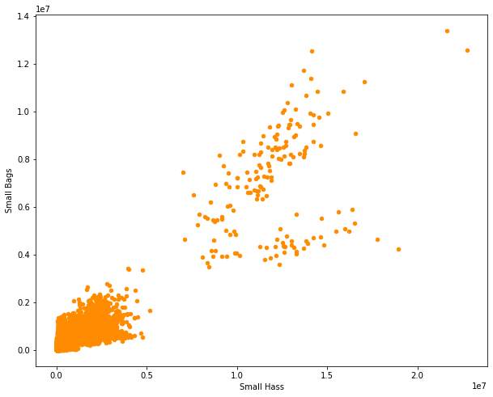

```python
avocado.plot(kind ='scatter', x = 'Small Hass', y ='Small Bags', color = 'darkorange', figsize = (10,8))
```

**You can customize your plot using the functions and argument listed above.**

#### **Exercise 1**

Import `beerhall.xlsx` data, and answer the following questions using the corresponding graphics.

```python
#compile this chunk
bh = pd.read_excel('beerhall.xlsx')
bh.head()
```

|  | County | Region_Name | Region_Code | Criminal | Beer | At_School | At_Public |
| --- | --- | --- | --- | --- | --- | --- | --- |
| 0 | Middlesex | South_Eastern | 1 | 200 | 541 | 560 | 434 |
| 1 | Surrey | South_Eastern | 1 | 160 | 504 | 630 | 482 |
| 2 | Kent | South_Eastern | 1 | 160 | 552 | 790 | 680 |
| 3 | Sussex | South Eastern | 1 | 147 | 295 | 820 | 678 |
| 4 | Hants | South_Eastern | 1 | 178 | 409 | 990 | 798 |

**1.1** How does the average of school attendance (At_School) changes by Region_Code? (Hint: use aggregate and line plot)

**1.2** Can you show the frequencies of Regions with an appropriate visual tool? Which region has the highest frequency?

**1.3** Do school attendance (At_School) and public attendance (At_Public) show a difference in terms of the distribution?

**1.4** How does the distribution of the criminals change by region?

**1.5** What is the relationship between criminal and public attendance?

In addition to the `plot()` constructor, pandas has also `pandas.plotting` module, providing more advanced plots compared to `plot` constructor.

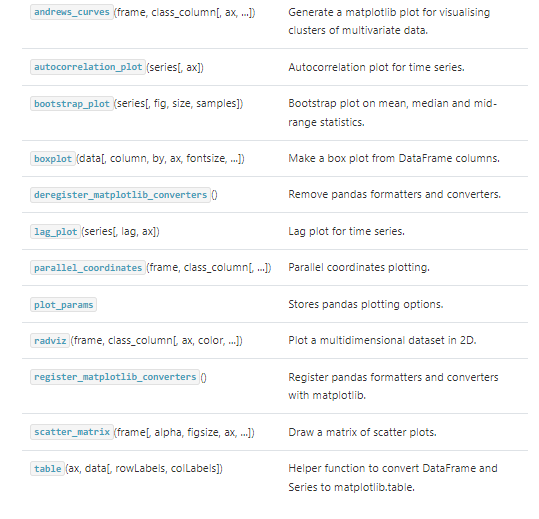

**Source:** [Pandas](https://pandas.pydata.org/pandas-docs/stable/reference/plotting.html)

Among these functions, `scatter_matrix()` will be our choice since it is an efficient tool to understand the data at the beginning.

```
array([[<matplotlib.axes._subplots.AxesSubplot object at 0x7f5c3a40dac0>,
      dtype=object)
```

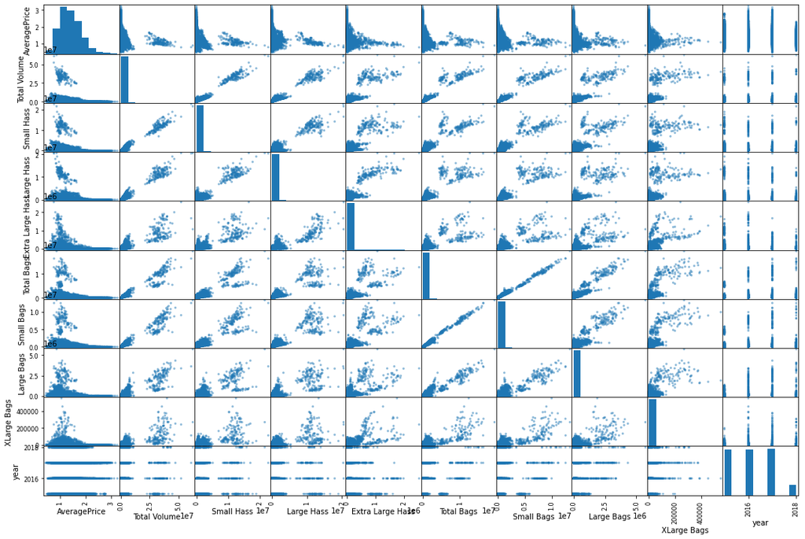

```python
from pandas.plotting import scatter_matrix
scatter_matrix(avocado, figsize = (18,12))
```

The function returns the histogram of each numerical variable as well as the scatter plot exploring the relationship between each pair of numerical variables.

#### **Exercise 2**

Try it yourself...

Import the `pandas.plotting` module and construct a scatter plot matrix for `beerhall.xlsx` data.

## **Matplotlib**

Matplotlib is a multi-platform data visualization library built on **NumPy arrays**, and designed to work with the broader SciPy stack. It enables interactive MATLAB-style plotting.

Although better tools like ggplot2 in R or seaborn in Python have been developed in recent years, matplotlib has still a sort of popularity.

Before talking about the usage of matplotlib in details, there are a few things that you should know about the package, which you have already used some of them above.

```python
#import the package
import matplotlib as mpl
import matplotlib.pyplot as plt
```

The `plt` interface is what we will use most often, as we shall see throughout this chapter.

**Setting Style**

We will use the `plt.style` directive to choose appropriate aesthetic styles for our figures. Here we will set the `classic` style, which ensures that the plots we create use the classic Matplotlib style:

`plt.style.use('classic')`

[You can see more options for customization.](https://colab.research.google.com/github/jakevdp/PythonDataScienceHandbook/blob/master/notebooks/04.11-Settings-and-Stylesheets.ipynb)

**Showing the plot**

If you are using Matplotlib from within a script, the function `plt.show()` is your friend. `plt.show()` starts an event loop, looks for all currently active figure objects, and opens one or more interactive windows that display your figure or figures.

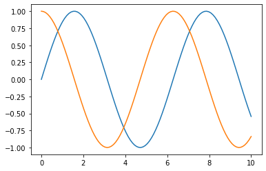

```python
import matplotlib.pyplot as plt
import numpy as np

x = np.linspace(0, 10, 100)

fig = plt.figure() #figure: Create a new figure, or activate an existing figure
plt.plot(x, np.sin(x))
plt.plot(x, np.cos(x))

plt.show()
```

**Saving Figures to File**

One nice feature of Matplotlib is the ability to save figures in a wide variety of formats. Saving a figure can be done using the `savefig()` command. For example, to save the previous figure as a PNG file, you can run this:

```python
fig.savefig('my_figure.png')
```

**Plot Frame**

Matplotlib has an ability to draw a multiple plot in one window.

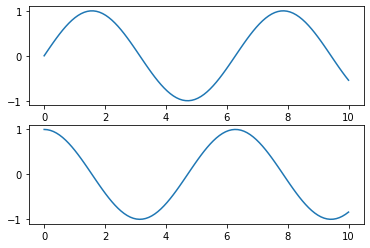

```python
plt.figure()  # create a plot figure

# create the first of two panels and set current axis
plt.subplot(2, 1, 1) # (rows, columns, panel number)
plt.plot(x, np.sin(x))

# create the second panel and set current axis
plt.subplot(2, 1, 2)
plt.plot(x, np.cos(x));
```

**Now, let's stary by drawing a basic line chart**

For all Matplotlib plots, we start by creating a figure and an axes. In their simplest form, a figure and axes can be created as follows:

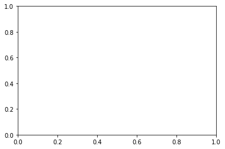

```python
fig = plt.figure()
ax = plt.axes()
```

In Matplotlib, the figure (an instance of the class plt.Figure) can be thought of as a single container that contains all the objects representing axes, graphics, text, and labels. The axes (an instance of the class plt.Axes) is what we see above: a bounding box with ticks and labels, which will eventually contain the plot elements that make up our visualization. Throughout this class, we'll commonly use the variable name fig to refer to a figure instance, and ax to refer to an axes instance or group of axes instances.

Once we have created an axes, we can use the ax.plot function to plot some data. Let's start with a simple sinusoid:

```python
fig = plt.figure()
ax = plt.axes()

x = np.linspace(0, 10, 1000)
ax.plot(x, np.sin(x));
```

[output not shown]

```python
plt.plot(x, np.sin(x));
```

[output not shown]

If we want to create a single figure with multiple lines, we can simply call the plot function multiple times

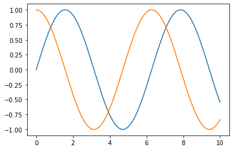

```python
plt.plot(x, np.sin(x))
plt.plot(x, np.cos(x));
```

**Adjusting the Plot: Line Colors and Styles**

The first adjustment you might wish to make to a plot is to control the line colors and styles. The plt.plot() function takes additional arguments that can be used to specify these. To adjust the color, you can use the color keyword, which accepts a string argument representing virtually any imaginable color. The color can be specified in a variety of ways:

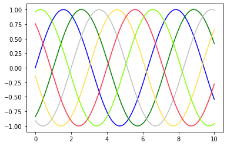

```python
plt.plot(x, np.sin(x - 0), color='blue')        # specify color by name
plt.plot(x, np.sin(x - 1), color='g')           # short color code (rgbcmyk)
plt.plot(x, np.sin(x - 2), color='0.75')        # Grayscale between 0 and 1
plt.plot(x, np.sin(x - 3), color='#FFDD44')     # Hex code (RRGGBB from 00 to FF)
plt.plot(x, np.sin(x - 4), color=(1.0,0.2,0.3)) # RGB tuple, values 0 to 1
plt.plot(x, np.sin(x - 5), color='chartreuse'); # all HTML color names supported
```

If no color is specified, Matplotlib will automatically cycle through a set of default colors for multiple lines.

Similarly, the line style can be adjusted using the linestyle keyword:

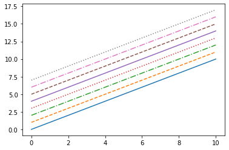

```python
plt.plot(x, x + 0, linestyle='solid')
plt.plot(x, x + 1, linestyle='dashed')
plt.plot(x, x + 2, linestyle='dashdot')
plt.plot(x, x + 3, linestyle='dotted');

# For short, you can use the following codes:
plt.plot(x, x + 4, linestyle='-')  # solid
plt.plot(x, x + 5, linestyle='--') # dashed
plt.plot(x, x + 6, linestyle='-.') # dashdot
plt.plot(x, x + 7, linestyle=':');  # dotted
```

**Adjusting the Plot: Axes Limits**

Matplotlib does a decent job of choosing default axes limits for your plot, but sometimes it's nice to have finer control. The most basic way to adjust axis limits is to use the plt.xlim() and plt.ylim() methods:

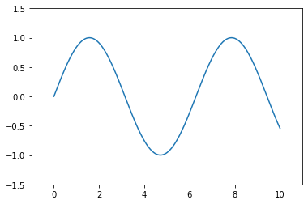

```python
plt.plot(x, np.sin(x))

plt.xlim(-1, 11)
plt.ylim(-1.5, 1.5);
```

If for some reason you'd like either axis to be displayed in reverse, you can simply reverse the order of the arguments:

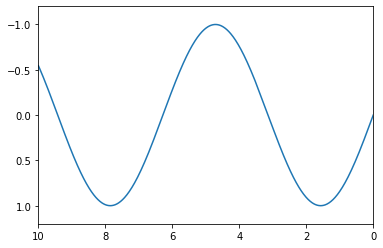

```python
plt.plot(x, np.sin(x))

plt.xlim(10, 0)
plt.ylim(1.2, -1.2);
```

A useful related method is `plt.axis()` (note here the potential confusion between *axes* with an *e*, and *axis* with an *i*). The `plt.axis()` method allows you to set the `x` and `y` limits with a single call, by passing a list which specifies `[xmin, xmax, ymin, ymax]`:

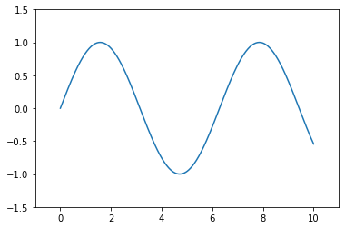

```python
plt.plot(x, np.sin(x))
plt.axis([-1, 11, -1.5, 1.5]);
```

The `plt.axis()` method goes even beyond this, allowing you to do things like automatically tighten the bounds around the current plot:

```python
plt.plot(x, np.sin(x))
plt.axis('tight');
```

[output not shown]

It allows even higher-level specifications, such as ensuring an equal aspect ratio so that on your screen, one unit in x is equal to one unit in y:

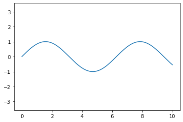

```python
plt.plot(x, np.sin(x))
plt.axis('equal');
```

For more information on axis limits and the other capabilities of the `plt.axis` method, refer to the `plt.axis` docstring.

**Labeling Plots**